# Software development patterns through git data mining

```python
import sys, os, getpass, warnings
warnings.filterwarnings('ignore')
from patterns.visualizer import Visualizer
```

Create a `Visualizer` object for a project, e.g., for Spack, `vis = Visualizer('spack')`. This brings in data from database and annotate it with *locc*, *locc+*, *locc-*, *change-size-cos* = *1-similarity* (**expensive call**). The data is cached locally after it's fetched from the database and subsequently loaded from disk, unless you specify the `cache=False` parameter, e.g., `vis.get_data(cache=False)`. Available projects include `'lammps', 'spack', 'petsc', 'Nek5000', 'nwchem', 'E3SM', 'qmcpack', 'qdpxx'` (the full list can be obtained with by calling the `Visualizer()` constructor without arguments.

The `get_data` method automatically removes changes associated with non-code files. The determination of what is code is made by including common suffixes, as well as checking manually a sampling of ECP projects for the suffixes used for things that can be labeled as code (vs. input simulation data, documentation, or generated files), for a list of suffixes, refer to the `Patterns.code_suffixes` list in patterns.py. This makes the analysis of decades of project data feasible. You can disable this if desired, by passing the `code_only=False` parameter to `get_data`. You can also explicitly remove non-code rows with `vis.remove_noncode()`.

```python
vis = Visualizer(project_name='NEK5000')
vis.get_data()
```

```
INFO: Loaded local cached copy of NEK5000 data.
INFO: Done computing averages.
```

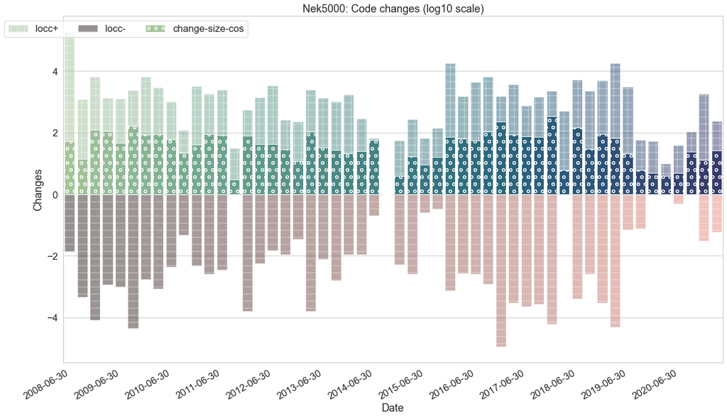

```python
df = vis.plot_overall_project_locc(time_range=None, log=True)
```

to focus on a given year and/or month, set *year* and *month* fields

```python
vis.set_year(2020)
vis.set_month(7)
```

to plot for a given year, provide *time_range='year'*

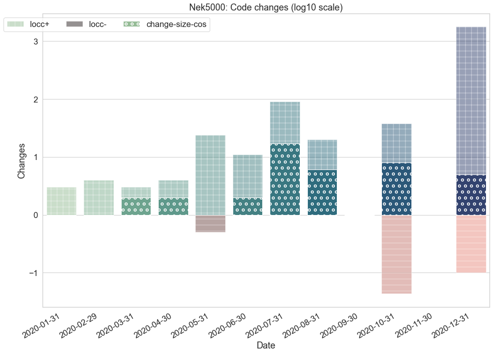

```python
df = vis.plot_overall_project_locc(time_range='year',log=True)
```

similarly to plot for a given month, set *time_range='month'*

| datetime | year | month | day | doy | locc-basic | locc | locc- | locc+ | change-size-cos | date |
| --- | --- | --- | --- | --- | --- | --- | --- | --- | --- | --- |
| 2020-07-01 | 4040 | 14 | 2 | 366 | 7 | 5 | inf | 0.477121 | 0.301030 | 2020-07-01 |
| 2020-07-02 | 0 | 0 | 0 | 0 | 0 | 0 | inf | -inf | -inf | 2020-07-02 |
| 2020-07-03 | 2020 | 7 | 3 | 185 | 10 | 6 | inf | 0.301030 | 0.000000 | 2020-07-03 |
| 2020-07-04 | 0 | 0 | 0 | 0 | 0 | 0 | inf | -inf | -inf | 2020-07-04 |
| 2020-07-05 | 0 | 0 | 0 | 0 | 0 | 0 | inf | -inf | -inf | 2020-07-05 |
| 2020-07-06 | 0 | 0 | 0 | 0 | 0 | 0 | inf | -inf | -inf | 2020-07-06 |
| 2020-07-07 | 0 | 0 | 0 | 0 | 0 | 0 | inf | -inf | -inf | 2020-07-07 |
| 2020-07-08 | 0 | 0 | 0 | 0 | 0 | 0 | inf | -inf | -inf | 2020-07-08 |
| 2020-07-09 | 0 | 0 | 0 | 0 | 0 | 0 | inf | -inf | -inf | 2020-07-09 |
| 2020-07-10 | 0 | 0 | 0 | 0 | 0 | 0 | inf | -inf | -inf | 2020-07-10 |
| 2020-07-11 | 0 | 0 | 0 | 0 | 0 | 0 | inf | -inf | -inf | 2020-07-11 |
| 2020-07-12 | 0 | 0 | 0 | 0 | 0 | 0 | inf | -inf | -inf | 2020-07-12 |
| 2020-07-13 | 2020 | 7 | 13 | 195 | 2 | 1 | inf | -inf | 0.000000 | 2020-07-13 |
| 2020-07-14 | 0 | 0 | 0 | 0 | 0 | 0 | inf | -inf | -inf | 2020-07-14 |
| 2020-07-15 | 0 | 0 | 0 | 0 | 0 | 0 | inf | -inf | -inf | 2020-07-15 |
| 2020-07-16 | 0 | 0 | 0 | 0 | 0 | 0 | inf | -inf | -inf | 2020-07-16 |
| 2020-07-17 | 0 | 0 | 0 | 0 | 0 | 0 | inf | -inf | -inf | 2020-07-17 |
| 2020-07-18 | 0 | 0 | 0 | 0 | 0 | 0 | inf | -inf | -inf | 2020-07-18 |
| 2020-07-19 | 0 | 0 | 0 | 0 | 0 | 0 | inf | -inf | -inf | 2020-07-19 |
| 2020-07-20 | 28280 | 98 | 280 | 2828 | 281 | 183 | inf | 1.929419 | 1.113943 | 2020-07-20 |

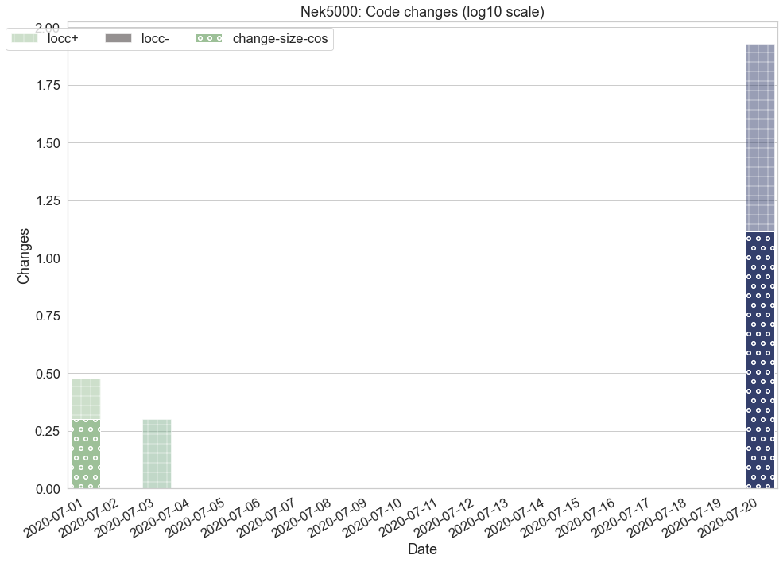

```python
vis.plot_overall_project_locc(time_range='month',log=True)
```

### Averages: Total changed lines over time

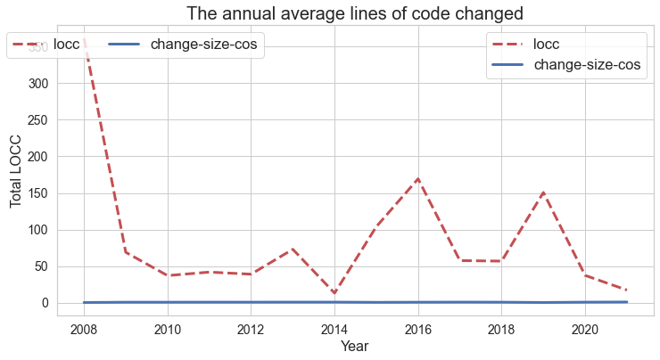

```python
vis.plot_total_locc_avg()
```

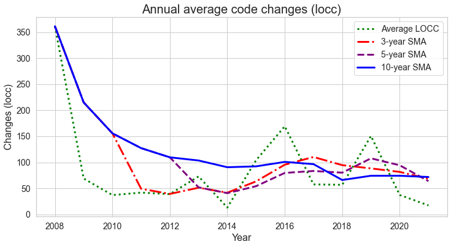

```python
vis.plot_total_locc_moving_avgs()
```

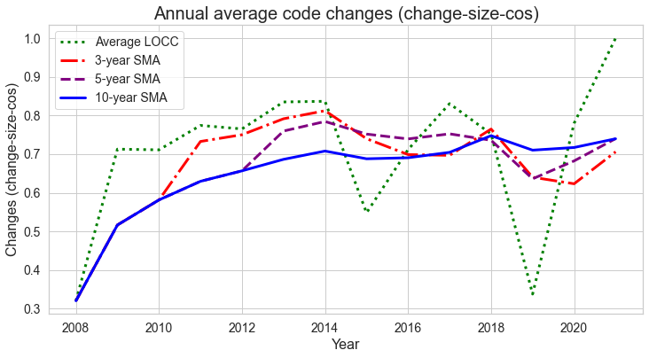

```python
vis.plot_total_locc_moving_avgs(column='change-size-cos')
```

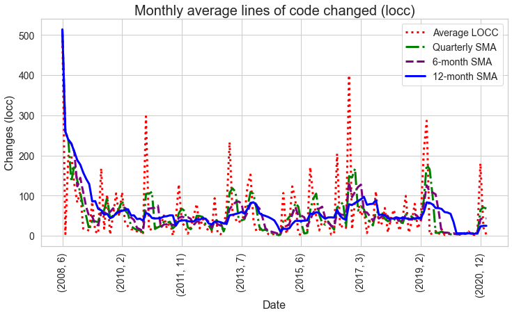

```python
vis.plot_total_locc_moving_avgs_M()
```

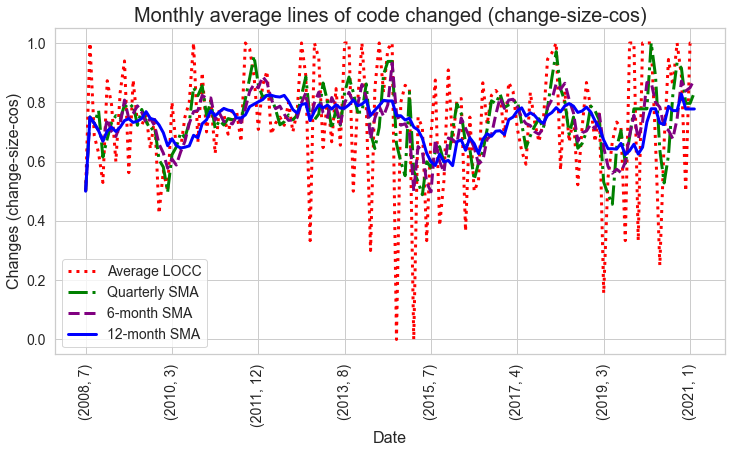

```python
vis.plot_total_locc_moving_avgs_M(column='change-size-cos')
```

### Custom visualizations with derived data

This reflects changed lines of code as reported in git commit diffs.

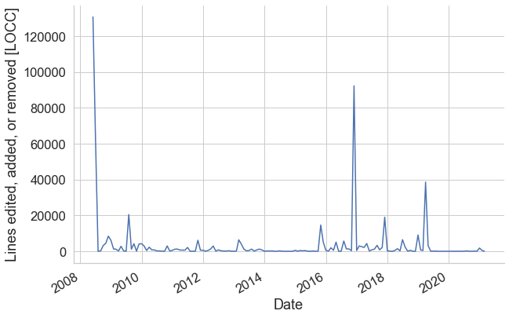

```python
df = vis.plot_project_locc_line()
```

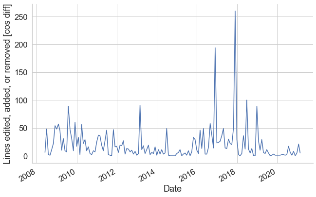

```python
df2 = vis.plot_project_locc_line(locc=False)
```

| datetime | year | month | day | doy | locc-basic | locc | locc- | locc+ | change-size-cos |
| --- | --- | --- | --- | --- | --- | --- | --- | --- | --- |
| 2008-05-31 00:00:00+00:00 | 528104 | 1315 | 6414 | 38237 | 130753 | 130727 | 4 | 130697 | 6 |
| 2008-06-30 00:00:00+00:00 | 246984 | 738 | 969 | 19665 | 63419 | 63210 | 68 | 62933 | 48 |
| 2008-07-31 00:00:00+00:00 | 8032 | 28 | 44 | 772 | 20 | 18 | 5 | 11 | 2 |
| 2008-08-31 00:00:00+00:00 | 2008 | 8 | 26 | 239 | 211 | 199 | 0 | 187 | 1 |
| 2008-09-30 00:00:00+00:00 | 32128 | 144 | 304 | 4208 | 3245 | 3218 | 2146 | 1045 | 11 |

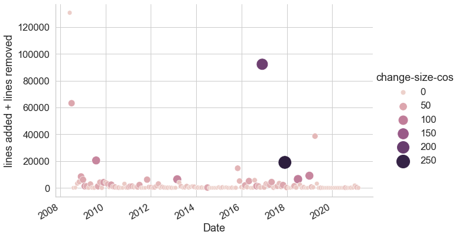

```python
import seaborn as sns
sns.set(font_scale=1.5)
with sns.axes_style("whitegrid"):
    g = sns.relplot(data=df2, x="datetime", y="locc", size="change-size-cos", hue="change-size-cos", sizes=(50, 500),
                    height=6, aspect=1.5, kind="scatter")
    g.ax.set_xlabel('Date')
    g.ax.set_ylabel('lines added + lines removed')
    g.fig.autofmt_xdate()
    g.fig.show()
df.head()
```

### Using a distance metric to adjust the size of the changes

We use the python textdistance module. The following algorithms have been integrated with the visualizer.

```
'cos', 'hamming', 'damerau_levenshtein', 'jaccard', 'jaro', 'jaro_winkler', 'bag', 'editex'
```

| datetime | year | month | day | doy | locc-basic | locc | locc- | locc+ | change-size-cos | change-size-jaccard |
| --- | --- | --- | --- | --- | --- | --- | --- | --- | --- | --- |
| 2008-05-31 00:00:00+00:00 | 528104 | 1315 | 6414 | 38237 | 130753 | 130727 | 4 | 130697 | 6 | 6 |
| 2008-06-30 00:00:00+00:00 | 246984 | 738 | 969 | 19665 | 63419 | 63210 | 68 | 62933 | 48 | 48 |
| 2008-07-31 00:00:00+00:00 | 8032 | 28 | 44 | 772 | 20 | 18 | 5 | 11 | 2 | 2 |
| 2008-08-31 00:00:00+00:00 | 2008 | 8 | 26 | 239 | 211 | 199 | 0 | 187 | 1 | 1 |
| 2008-09-30 00:00:00+00:00 | 32128 | 144 | 304 | 4208 | 3245 | 3218 | 2146 | 1045 | 11 | 11 |

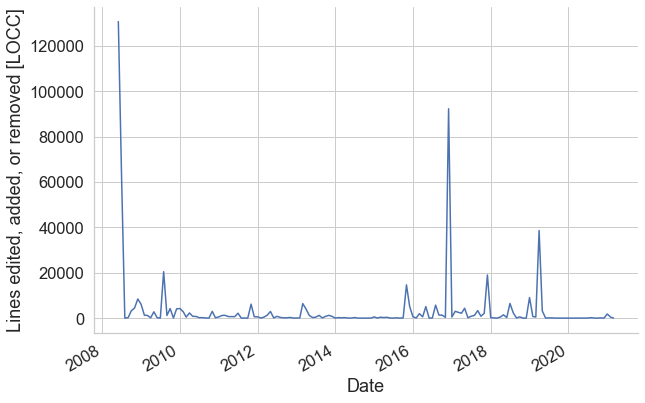

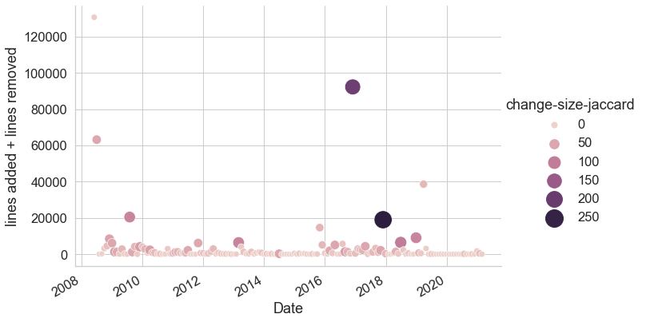

```python
diff_alg = 'jaccard'
vis.set_diff_alg(diff_alg)
df = vis.plot_project_locc_line(diff_alg=diff_alg, log=False)
import seaborn as sns
sns.set(font_scale=1.5)
with sns.axes_style("whitegrid"):
    g = sns.relplot(data=df, x="datetime", y="locc", size="change-size-%s" % diff_alg, hue="change-size-%s" % diff_alg, sizes=(50, 500),
                    height=6, aspect=1.5, kind="scatter")
    g.ax.set_xlabel('Date')
    g.ax.set_ylabel('lines added + lines removed')
    g.fig.autofmt_xdate()
    g.fig.show()
df.head()
```

## Change size over time

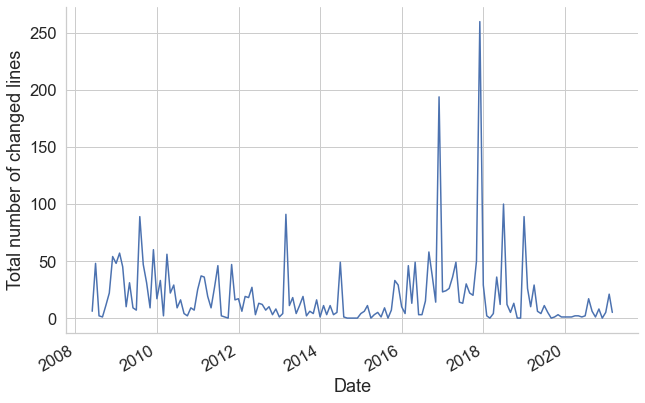

```python
df = vis.plot_proj_change_size(time_range=None)
```

Similarly, we can 'zoom' into a specific year

```
(                            year  month  day   doy  locc-basic  locc  locc-  \
 datetime
 2020-01-31 00:00:00+00:00   2020      1   29    29           5     4      0
 2020-02-29 00:00:00+00:00   2020      2   19    50           6     5      0
 2020-03-31 00:00:00+00:00   4040      6   39   159          11     7      0
 2020-04-30 00:00:00+00:00   6060     12   60   333          12     8      0
 2020-05-31 00:00:00+00:00   8080     20   64   548          44    35      2
 2020-06-30 00:00:00+00:00   6060     18   45   501          23    17      0
 2020-07-31 00:00:00+00:00  36360    126  298  3574         300   195      0
 2020-08-31 00:00:00+00:00  14140     56   38  1529          36    28      0
 2020-09-30 00:00:00+00:00   2020      9    8   252           4     2      0
 2020-10-31 00:00:00+00:00  18180     90  279  2745         141   101     23
 2020-11-30 00:00:00+00:00      0      0    0     0           0     0      0
 2020-12-31 00:00:00+00:00  20200    120  190  3540        1817  1801     10

                            locc+  change-size-cos  change-size-jaccard
 datetime
 2020-01-31 00:00:00+00:00      3                1                    1
 2020-02-29 00:00:00+00:00      4                1                    1
 2020-03-31 00:00:00+00:00      3                2                    2
 2020-04-30 00:00:00+00:00      4                2                    2
 2020-05-31 00:00:00+00:00     24                1                    1
 2020-06-30 00:00:00+00:00     11                2                    2
 2020-07-31 00:00:00+00:00     90               17                   17
 2020-08-31 00:00:00+00:00     20                6                    6
 2020-09-30 00:00:00+00:00      0                1                    1
 2020-10-31 00:00:00+00:00     38                8                    8
 2020-11-30 00:00:00+00:00      0                0                    0
 2020-12-31 00:00:00+00:00   1775                5                    5  ,
 <AxesSubplot:xlabel='Date', ylabel='Total number of changed lines'>)
```

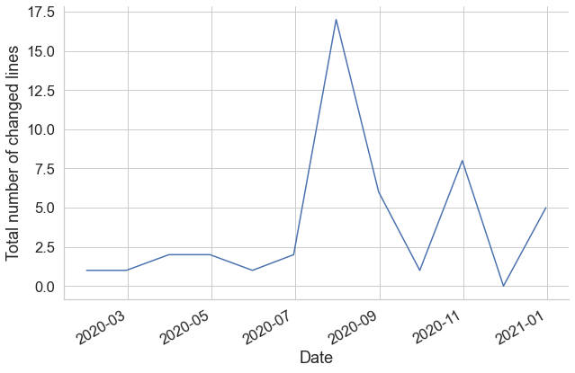

```python
vis.plot_proj_change_size(time_range='year')
```

Or a specific year range

| datetime | year | month | day | doy | locc-basic | locc | locc- | locc+ | change-size-cos | change-size-jaccard | date |
| --- | --- | --- | --- | --- | --- | --- | --- | --- | --- | --- | --- |
| 2008-06-30 00:00:00+00:00 | 775088 | 2053 | 7383 | 57902 | 194172 | 193937 | -1.857332 | 5.286973 | 54 | 1.732394 | 2008-06-30 |
| 2008-09-30 00:00:00+00:00 | 42168 | 180 | 374 | 5219 | 3476 | 3435 | -3.332640 | 3.094471 | 14 | 1.146128 | 2008-09-30 |
| 2008-12-31 00:00:00+00:00 | 385536 | 2132 | 2183 | 61308 | 19469 | 19015 | -4.079145 | 3.817036 | 124 | 2.093422 | 2008-12-31 |
| 2009-03-31 00:00:00+00:00 | 319431 | 258 | 2624 | 5657 | 3069 | 2621 | -2.928396 | 3.122216 | 112 | 2.049218 | 2009-03-31 |
| 2009-06-30 00:00:00+00:00 | 114513 | 260 | 470 | 6568 | 3693 | 3014 | -3.016197 | 3.112940 | 47 | 1.672098 | 2009-06-30 |
| 2009-09-30 00:00:00+00:00 | 458052 | 1743 | 4612 | 50437 | 26653 | 25835 | -4.355490 | 3.370143 | 167 | 2.222716 | 2009-09-30 |
| 2009-12-31 00:00:00+00:00 | 269206 | 1500 | 2018 | 43520 | 9617 | 8356 | -2.768638 | 3.813448 | 86 | 1.934498 | 2009-12-31 |
| 2010-03-31 00:00:00+00:00 | 265320 | 276 | 1720 | 5974 | 6883 | 5523 | -3.059185 | 3.479575 | 91 | 1.959041 | 2010-03-31 |
| 2010-06-30 00:00:00+00:00 | 182910 | 433 | 1401 | 11673 | 2206 | 1722 | -2.361728 | 3.003461 | 60 | 1.778151 | 2010-06-30 |
| 2010-09-30 00:00:00+00:00 | 54270 | 199 | 362 | 5559 | 414 | 278 | -1.322219 | 2.082785 | 22 | 1.342423 | 2010-09-30 |
| 2010-12-31 00:00:00+00:00 | 102510 | 582 | 732 | 16856 | 3860 | 3643 | -2.315970 | 3.507721 | 41 | 1.612784 | 2010-12-31 |
| 2011-03-31 00:00:00+00:00 | 261430 | 226 | 1718 | 4619 | 3923 | 3070 | -2.580925 | 3.263873 | 92 | 1.963788 | 2011-03-31 |
| 2011-06-30 00:00:00+00:00 | 217188 | 587 | 1883 | 16313 | 4144 | 3464 | -2.457882 | 3.397419 | 82 | 1.913814 | 2011-06-30 |
| 2011-09-30 00:00:00+00:00 | 8044 | 29 | 86 | 841 | 54 | 43 | inf | 1.505150 | 3 | 0.477121 | 2011-09-30 |
| 2011-12-31 00:00:00+00:00 | 180990 | 966 | 2176 | 28768 | 7755 | 7319 | -3.801609 | 2.740363 | 80 | 1.903090 | 2011-12-31 |
| 2012-03-31 00:00:00+00:00 | 108648 | 127 | 785 | 2996 | 1926 | 1766 | -2.250420 | 3.154728 | 43 | 1.633468 | 2012-03-31 |
| 2012-06-30 00:00:00+00:00 | 118708 | 276 | 983 | 7570 | 4084 | 3788 | -1.819544 | 3.534787 | 43 | 1.633468 | 2012-06-30 |
| 2012-09-30 00:00:00+00:00 | 76456 | 302 | 614 | 8646 | 784 | 569 | -1.959041 | 2.419956 | 29 | 1.462398 | 2012-09-30 |
| 2012-12-31 00:00:00+00:00 | 30180 | 165 | 202 | 4774 | 442 | 351 | -1.462398 | 2.363612 | 12 | 1.079181 | 2012-12-31 |
| 2013-03-31 00:00:00+00:00 | 235521 | 247 | 1535 | 5514 | 12205 | 10446 | -3.794070 | 3.391464 | 106 | 2.025306 | 2013-03-31 |
| 2013-06-30 00:00:00+00:00 | 82533 | 196 | 849 | 5512 | 2241 | 1864 | -2.110590 | 3.132900 | 33 | 1.518514 | 2013-06-30 |
| 2013-09-30 00:00:00+00:00 | 74481 | 273 | 389 | 7520 | 2426 | 2047 | -2.797960 | 3.017033 | 27 | 1.431364 | 2013-09-30 |
| 2013-12-31 00:00:00+00:00 | 58377 | 312 | 172 | 8770 | 2183 | 1993 | -1.954243 | 3.233757 | 21 | 1.322219 | 2013-12-31 |
| 2014-03-31 00:00:00+00:00 | 74518 | 73 | 545 | 1622 | 751 | 566 | -1.959041 | 2.462398 | 25 | 1.397940 | 2014-03-31 |
| 2014-06-30 00:00:00+00:00 | 118826 | 342 | 975 | 9515 | 467 | 269 | -0.698970 | 1.819544 | 57 | 1.755875 | 2014-06-30 |
| 2014-09-30 00:00:00+00:00 | 2014 | 7 | 10 | 191 | 4 | 2 | inf | -inf | 1 | 0.000000 | 2014-09-30 |
| 2014-12-31 00:00:00+00:00 | 14098 | 80 | 106 | 2322 | 819 | 534 | -2.285557 | 1.748188 | 4 | 0.602060 | 2014-12-31 |
| 2015-03-31 00:00:00+00:00 | 44330 | 39 | 184 | 705 | 701 | 684 | -2.593286 | 2.439333 | 17 | 1.230449 | 2015-03-31 |
| 2015-06-30 00:00:00+00:00 | 28210 | 69 | 207 | 1860 | 743 | 407 | -0.602060 | 1.826075 | 9 | 0.954243 | 2015-06-30 |
| 2015-09-30 00:00:00+00:00 | 42315 | 163 | 302 | 4599 | 280 | 213 | -0.477121 | 2.155336 | 16 | 1.204120 | 2015-09-30 |
| 2015-12-31 00:00:00+00:00 | 304265 | 1586 | 2937 | 46505 | 21039 | 20317 | -3.134177 | 4.260858 | 72 | 1.857332 | 2015-12-31 |
| 2016-03-31 00:00:00+00:00 | 159264 | 168 | 1321 | 4048 | 3318 | 2593 | -2.562293 | 3.176959 | 63 | 1.799341 | 2016-03-31 |
| 2016-06-30 00:00:00+00:00 | 290304 | 592 | 2640 | 16230 | 5487 | 5120 | -2.591065 | 3.639785 | 55 | 1.740363 | 2016-06-30 |
| 2016-09-30 00:00:00+00:00 | 294336 | 1191 | 2269 | 34080 | 9458 | 8364 | -2.910091 | 3.810031 | 110 | 2.041393 | 2016-09-30 |
| 2016-12-31 00:00:00+00:00 | 556416 | 3047 | 4132 | 88625 | 93952 | 93096 | -4.957646 | 3.185259 | 231 | 2.363612 | 2016-12-31 |
| 2017-03-31 00:00:00+00:00 | 217836 | 224 | 1696 | 5163 | 8421 | 7716 | -3.527888 | 3.560982 | 86 | 1.934498 | 2017-03-31 |
| 2017-06-30 00:00:00+00:00 | 227921 | 518 | 2589 | 14761 | 5450 | 5312 | -3.646208 | 2.872739 | 76 | 1.880814 | 2017-06-30 |
| 2017-09-30 00:00:00+00:00 | 193632 | 762 | 1958 | 22124 | 5563 | 5323 | -3.561459 | 3.158362 | 72 | 1.857332 | 2017-09-30 |
| 2017-12-31 00:00:00+00:00 | 752341 | 4065 | 5043 | 117227 | 23994 | 21385 | -4.218693 | 3.348305 | 339 | 2.530200 | 2017-12-31 |
| 2018-03-31 00:00:00+00:00 | 18162 | 23 | 240 | 653 | 580 | 540 | -0.000000 | 2.698101 | 6 | 0.778151 | 2018-03-31 |
| 2018-06-30 00:00:00+00:00 | 393510 | 1066 | 3751 | 30015 | 8593 | 8145 | -3.392697 | 3.718253 | 148 | 2.170262 | 2018-06-30 |
| 2018-09-30 00:00:00+00:00 | 90810 | 352 | 763 | 10055 | 3129 | 2876 | -2.594393 | 3.348305 | 30 | 1.477121 | 2018-09-30 |
| 2018-12-31 00:00:00+00:00 | 230052 | 1368 | 1376 | 39452 | 9806 | 9082 | -3.530200 | 3.696182 | 89 | 1.949390 | 2018-12-31 |
| 2019-03-31 00:00:00+00:00 | 480522 | 623 | 5892 | 17269 | 40049 | 39795 | -4.323231 | 4.266984 | 65 | 1.812913 | 2019-03-31 |
| 2019-06-30 00:00:00+00:00 | 64608 | 164 | 692 | 4667 | 3443 | 3272 | -1.146128 | 3.489537 | 21 | 1.322219 | 2019-06-30 |
| 2019-09-30 00:00:00+00:00 | 20190 | 76 | 157 | 2153 | 118 | 94 | -1.113943 | 1.755875 | 6 | 0.778151 | 2019-09-30 |
| 2019-12-31 00:00:00+00:00 | 14133 | 77 | 163 | 2288 | 81 | 67 | inf | 1.724276 | 5 | 0.698970 | 2019-12-31 |
| 2020-03-31 00:00:00+00:00 | 8080 | 9 | 87 | 238 | 22 | 16 | inf | 1.000000 | 4 | 0.602060 | 2020-03-31 |
| 2020-06-30 00:00:00+00:00 | 20200 | 50 | 169 | 1382 | 79 | 60 | -0.301030 | 1.591065 | 5 | 0.698970 | 2020-06-30 |
| 2020-09-30 00:00:00+00:00 | 52520 | 191 | 344 | 5355 | 340 | 225 | inf | 2.041393 | 24 | 1.380211 | 2020-09-30 |
| 2020-12-31 00:00:00+00:00 | 38380 | 210 | 469 | 6285 | 1958 | 1902 | -1.518514 | 3.258398 | 13 | 1.113943 | 2020-12-31 |
| 2021-03-31 00:00:00+00:00 | 52546 | 31 | 255 | 410 | 639 | 450 | -1.230449 | 2.387390 | 26 | 1.414973 | 2021-03-31 |

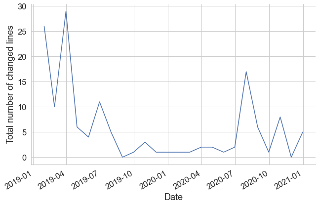

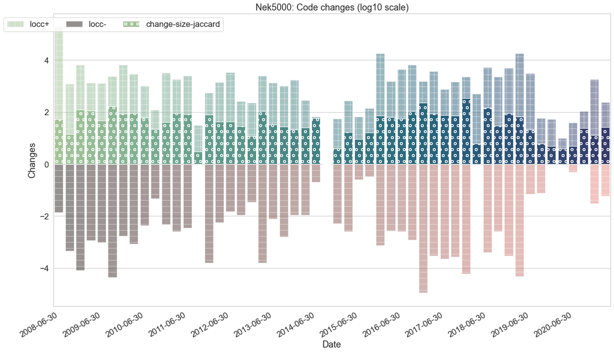

```python
vis.select_year_range(2019,2020)
vis.plot_proj_change_size(time_range='year-year')
vis.plot_overall_project_locc(time_range='year-year',log=True)
```

we can zoom into a month

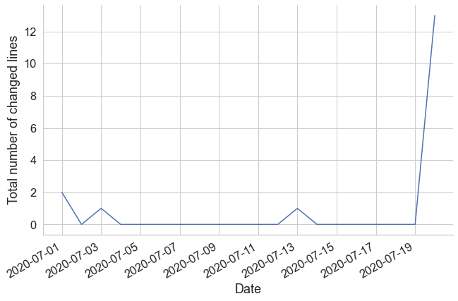

```python
_ = vis.plot_proj_change_size(time_range='month')
```

Or a month range

```
(                            year  month  day   doy  locc-basic  locc  locc-  \
 datetime
 2019-05-31 00:00:00+00:00  12114     30  110   830          26    16      2
 2019-06-30 00:00:00+00:00  30285     90  371  2636         153   107      8
 2019-07-31 00:00:00+00:00  14133     49  120  1387         106    85     13
 2019-08-31 00:00:00+00:00      0      0    0     0           0     0      0
 2019-09-30 00:00:00+00:00   6057     27   37   766          12     9      0
 2019-10-31 00:00:00+00:00   6057     30   60   879          60    50      0
 2019-11-30 00:00:00+00:00   2019     11   19   323           3     2      0
 2019-12-31 00:00:00+00:00      0      0    0     0           0     0      0
 2020-01-31 00:00:00+00:00      0      0    0     0           0     0      0
 2020-02-29 00:00:00+00:00      0      0    0     0           0     0      0
 2020-03-31 00:00:00+00:00      0      0    0     0           0     0      0
 2020-04-30 00:00:00+00:00      0      0    0     0           0     0      0
 2020-05-31 00:00:00+00:00   8080     20   64   548          44    35      2
 2020-06-30 00:00:00+00:00   6060     18   45   501          23    17      0
 2020-07-31 00:00:00+00:00  36360    126  298  3574         300   195      0
 2020-08-31 00:00:00+00:00  14140     56   38  1529          36    28      0
 2020-09-30 00:00:00+00:00   2020      9    8   252           4     2      0
 2020-10-31 00:00:00+00:00  18180     90  279  2745         141   101     23

                            locc+  change-size-cos  change-size-jaccard
 datetime
 2019-05-31 00:00:00+00:00      4                4                    4
 2019-06-30 00:00:00+00:00     53               11                   11
 2019-07-31 00:00:00+00:00     51                5                    5
 2019-08-31 00:00:00+00:00      0                0                    0
 2019-09-30 00:00:00+00:00      6                1                    1
 2019-10-31 00:00:00+00:00     40                3                    3
 2019-11-30 00:00:00+00:00      1                1                    1
 2019-12-31 00:00:00+00:00      0                0                    0
 2020-01-31 00:00:00+00:00      0                0                    0
 2020-02-29 00:00:00+00:00      0                0                    0
 2020-03-31 00:00:00+00:00      0                0                    0
 2020-04-30 00:00:00+00:00      0                0                    0
 2020-05-31 00:00:00+00:00     24                1                    1
 2020-06-30 00:00:00+00:00     11                2                    2
 2020-07-31 00:00:00+00:00     90               17                   17
 2020-08-31 00:00:00+00:00     20                6                    6
 2020-09-30 00:00:00+00:00      0                1                    1
 2020-10-31 00:00:00+00:00     38                8                    8  ,
 <AxesSubplot:xlabel='Date', ylabel='Total number of changed lines'>)
```

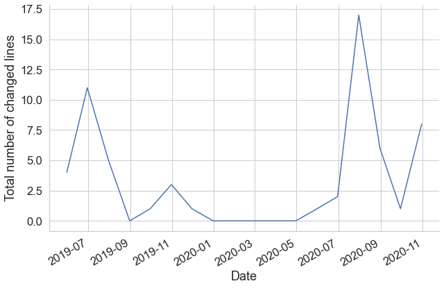

```python
vis.select_month_range(5,11)
vis.plot_proj_change_size(time_range='month-month')
```

## More patterns

Here we look at a combination of the the high-churn and domain champion patterns. Basically we are focusing on the files that have the most changes and restricting the developers by those with the biggest contributions.

| author filepath | stefanke | hackljf | Stefan Kerkemeier | Stefan K | Paul Fischer | fischer | Stefan | jlottes | Mrugesh Shringarpure | Katherine Heisey |
| --- | --- | --- | --- | --- | --- | --- | --- | --- | --- | --- |
| core/3rd_party/blas.f | 0 | 0 | 0 | 16627 | 0 | 0 | 0 | 0 | 0 | 0 |
| core/blas.f | 16628 | 0 | 0 | 0 | 0 | 0 | 0 | 0 | 0 | 0 |
| core/mxm_std.f | 32 | 0 | 0 | 10 | 0 | 3642 | 0 | 0 | 1047 | 0 |
| core/navier1.f | 3840 | 4 | 0 | 473 | 0 | 817 | 67 | 0 | 2 | 0 |
| core/navier5.f | 2911 | 0 | 0 | 713 | 0 | 1428 | 384 | 0 | 1 | 0 |

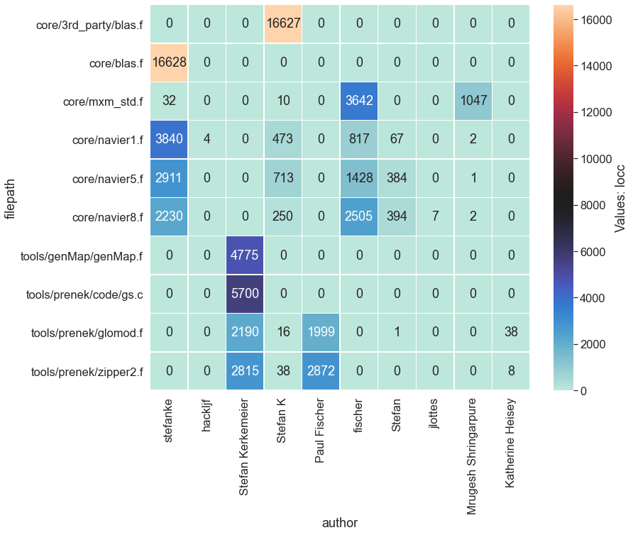

```python
N = 10
vis.set_max_label_length(30)
top_N = vis.plot_top_N_heatmap(N, value_column='locc')
top_N.head()
```

| author filepath | Stefan K | stefanke | Stefan | fischer | Paul Fischer | hackljf | heisey | jlottes | Katherine Heisey | Stefan Kerkemeier |
| --- | --- | --- | --- | --- | --- | --- | --- | --- | --- | --- |
| core/comm_mpi.f | 13 | 23 | 9 | 10 | 1 | 0 | 8 | 1 | 0 | 0 |
| core/connect2.f | 9 | 32 | 11 | 27 | 0 | 2 | 21 | 0 | 0 | 0 |
| core/drive1.f | 15 | 22 | 20 | 8 | 0 | 2 | 4 | 0 | 0 | 0 |
| core/drive2.f | 10 | 24 | 13 | 17 | 0 | 0 | 7 | 0 | 0 | 0 |
| core/ic.f | 13 | 28 | 13 | 26 | 0 | 4 | 14 | 0 | 0 | 0 |

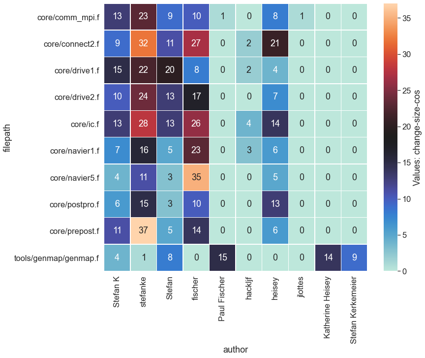

```python
import seaborn as sns
top_N = vis.plot_top_N_heatmap(N, value_column='change-size-cos')
top_N.head()
```

```python
from patterns.patterns import Patterns
df = vis.commit_data
```

```python
vis.reset()
vis.annotate_metrics(diff_alg='cos')
file_dev_locc = vis.make_file_developer_df(value_column='locc')
file_dev_diff = vis.make_file_developer_df(value_column='change-size-cos')
```

```python
diff_df = file_dev_locc.sub(file_dev_diff, axis=0)
print(diff_df.shape)
diff_df.head()
```

```
(967, 58)
```

| author filepath | Adam Peplinski | Aleksandr Obabko | Ananias Tomboulides | Blair Archibald | Charles | Clio Saglietti | Dillon Shaver | Evelyn Otero | George | James Lottes | ... | nchristensen | negips | nicooff | oanam | obabko | peet | stefanke | stgeke | tautges | vijaysm |
| --- | --- | --- | --- | --- | --- | --- | --- | --- | --- | --- | --- | --- | --- | --- | --- | --- | --- | --- | --- | --- | --- |
| .travis.yml | 108.0 | 0.0 | 0.0 | 0.0 | NaN | 0.0 | 0.0 | 0.0 | 0.0 | 0.0 | ... | 0.0 | 0.0 | 0.0 | 0.0 | 0.0 | 0.0 | 0.0 | 0.0 | 0.0 | 0.0 |
| 3rd_party/blasLapack/dasum.f | NaN | NaN | NaN | NaN | NaN | NaN | NaN | NaN | NaN | NaN | ... | NaN | NaN | NaN | NaN | NaN | NaN | NaN | NaN | NaN | NaN |
| 3rd_party/blasLapack/daxpy.f | NaN | NaN | NaN | NaN | NaN | NaN | NaN | NaN | NaN | NaN | ... | NaN | NaN | NaN | NaN | NaN | NaN | NaN | NaN | NaN | NaN |
| 3rd_party/blasLapack/dbdsqr.f | NaN | NaN | NaN | NaN | NaN | NaN | NaN | NaN | NaN | NaN | ... | NaN | NaN | NaN | NaN | NaN | NaN | NaN | NaN | NaN | NaN |
| 3rd_party/blasLapack/dcabs1.f | NaN | NaN | NaN | NaN | NaN | NaN | NaN | NaN | NaN | NaN | ... | NaN | NaN | NaN | NaN | NaN | NaN | NaN | NaN | NaN | NaN |

5 rows × 58 columns

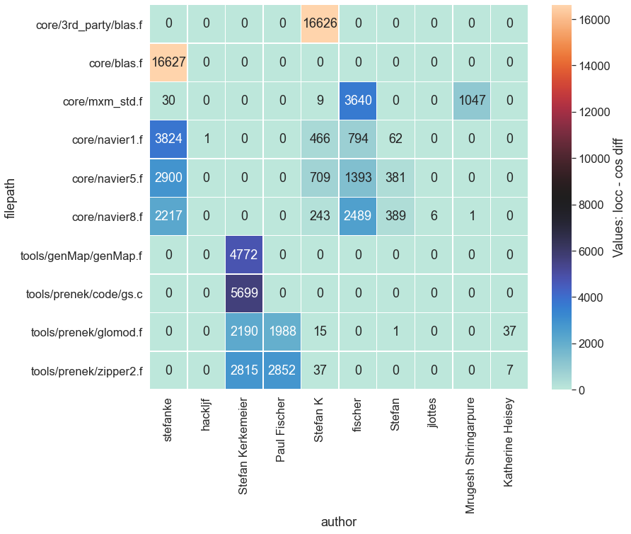

```python
df = vis.commit_data
df['locc - cos diff'] = df['locc']-df['change-size-cos']
d = vis.plot_top_N_heatmap(top_N = 10, value_column='locc - cos diff', my_df=df)
```

## Did anything unusual happen in 2020?

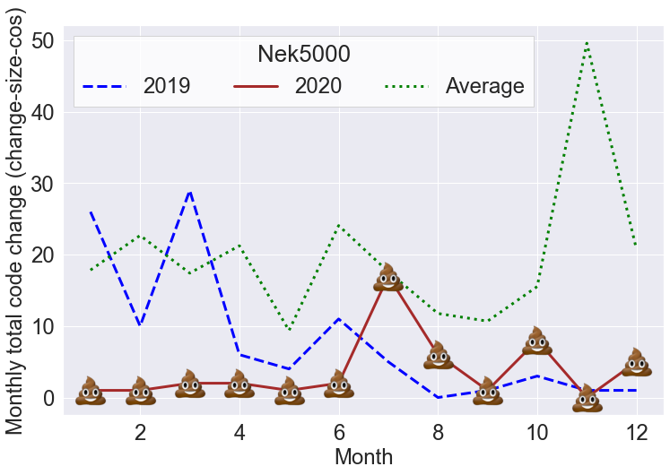

```python
vis.how_was_2020('change-size-cos')
```

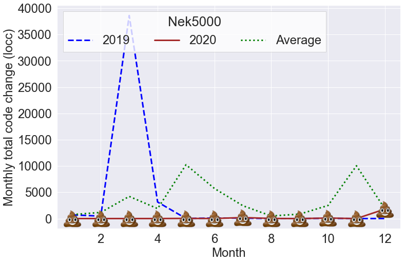

```python
vis.how_was_2020('locc')
```